# Hong Kong Housing Purchase vs Rent Analysis

Mitsuaki Takeo

June 2016

## Introduction

Housing prices in Hong Kong in on an unprecedented incline year on year. Buying real estate is always better than renting is a common sentiment here in Hong Kong. But is that necessarily true? Should you always opt to buy instead of rent under any market condition? I hope by reading this short analysis I can help stimulate some discourse between purchasing and renting. As is with everything else in life, nothing is for certain.

Data source: Purchase and rent data obtained from https://data.gov.hk/en-data/dataset/hk-rvd-tsinfo_rvd-property-market-statistics

Prior to analysing the data pulled from the data.gov.hk site the data had to be cleaned. Data was reformatted in a more R friendly format. The original data presented was segregated by housing class. Below is a summary of the classes:

Class A - Less than 40 m<sup>2</sup>  
Class B - 40 m<sup>2</sup> to 69.9 m<sup>2</sup>  
Class C - 70 m<sup>2</sup> to 99.9 m<sup>2</sup>  
Class D - 100 m<sup>2</sup> to 159.9 m<sup>2</sup>  
Class E - 160 m<sup>2</sup> or above

```r
#Data Preparation
#Create lists
#Rent
RentClassA <- as.matrix(RentClassA)
RentClassB <- as.matrix(RentClassB)
RentClassC <- as.matrix(RentClassC)
RentClassD <- as.matrix(RentClassD)
RentClassE <- as.matrix(RentClassE)
Rent <- list(RentClassA=RentClassA,RentClassB=RentClassB,RentClassC=RentClassC,RentClassD=RentClassD,RentClassE=RentClassE)

#Buy
BuyClassA <- as.matrix(BuyClassA)
BuyClassB <- as.matrix(BuyClassB)
BuyClassC <- as.matrix(BuyClassC)
BuyClassD <- as.matrix(BuyClassD)
BuyClassE <- as.matrix(BuyClassE)
Buy <- list(BuyClassA=BuyClassA,BuyClassB=BuyClassB,BuyClassC=BuyClassC,BuyClassD=BuyClassD,BuyClassE=BuyClassE)

#sapply to calculate the mean across all regions in Hong Kong
RentAvg <- t(sapply(Rent, colMeans))
BuyAvg <- t(sapply(Buy, colMeans))

#Purchase to Rent Ratio
Ratio <- BuyAvg /(RentAvg * 12)
RatioAvg <- apply(Ratio, 2, mean)

#Final Averages across all housing classes
RentTAvg <- apply(RentAvg, 2, mean)
RentTAvg12 <- RentTAvg*12
BuyTAvg <- apply(BuyAvg, 2, mean)

TAvg <- rbind(RentTAvg12,BuyTAvg,RatioAvg)
```

From the code above the Purchase to Rent Ratio was calculated using the original data. The purchase to rent ratio is a comparison between purchasing a home versus renting using the following equation:

Purchasae to Rent ratio = Average list price/(Average rent * 12)

As a baseline a ratio of 20 is typically seen as the threshold of purchasing versus renting. Ratio under 20 would suggest that buying is better than renting and therefore above 20 would be better to rent than buy.

## Analysis by Housing Class

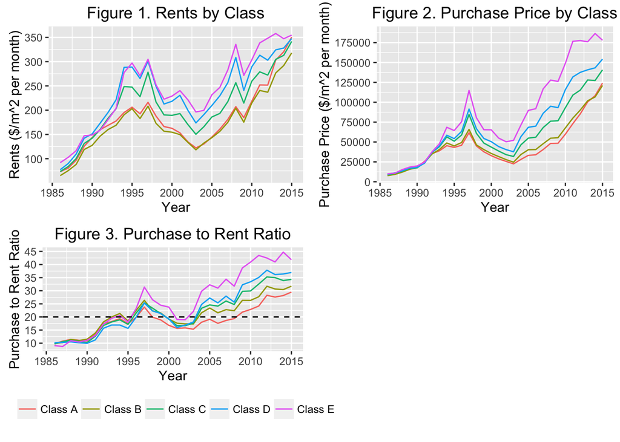

```r
library(ggplot2)
library(reshape2)
library(grid)
library(gridExtra)

plot1 <- ggplot(melt(RentAvg),aes(x=Var2,y=value, col=Var1)) + geom_line() +
                ggtitle("Figure 1. Rents by Class") +
                theme(legend.position="none") +
                scale_x_continuous(name="Year", breaks=seq(1985,2015,5)) +
                scale_y_continuous(name="Rents ($/m^2 per month)", breaks=seq(0,400,50))


plot2 <- ggplot(melt(BuyAvg),aes(x=Var2,y=value, col=Var1)) + geom_line() +
                ggtitle("Figure 2. Purchase Price by Class") +
                theme(legend.position="none") +
                scale_x_continuous(name="Year", breaks=seq(1985,2015,5)) +
                scale_y_continuous(name="Purchase Price ($/m^2 per month)", breaks=seq(0,200000,25000))


plot3 <- ggplot(melt(Ratio),aes(x=Var2,y=value, color=Var1)) + geom_line() +
                ggtitle("Figure 3. Purchase to Rent Ratio") +
                theme(legend.title=element_blank(), legend.position="bottom") +
                scale_x_continuous(name="Year", breaks=seq(1985,2015,5)) +
                scale_y_continuous(name="Purchase to Rent Ratio", breaks=seq(0,50,5)) +
                geom_hline(aes(yintercept=20), linetype="dashed") +
                scale_color_discrete(name="Class",
                                   breaks=c("BuyClassA","BuyClassB","BuyClassC","BuyClassD","BuyClassE"),
                                   labels=c("Class A","Class B","Class C","Class D","Class E"))
grid.arrange(plot1, plot2, plot3, nrow=2, ncol=2)
```

The above 3 charts are the line chart ggplots for rent, purchase and ratio data by class. From the 3 figures it is evident that there was a huge upswing in 2003 and continued this course towards 2015.

In Figure 3. we can see that the ratio for all class had surpassed well beyond the threshold of 20 by 2015. Again the cross over happened around 2003. This would suggest that even though both rent prices and purchase price are both in an upswing, the purchase price is clearly outpacing the cost to rent.

An interesting caveat from Figure 1. that Class A (smallest Housing Class) rental cost has exceeded all classes except for Class E. In other words, on average it costs the same amount to rent a Class A than a Class D which is 2-3 times it’s size.

In the next section we will look at the data wholistically and visualize the disparity between renting and purchasing.

## Purchase vs Rent Disparity

Before plotting the data some adjustments had to be made in order to correctly plot on ggplot. Below is the preparation to convert the data from a matrix format to a dataframe.

```r
#Converting TAvg from a matrix to a dataframe
dfTAvg <- as.data.frame(t(TAvg))
#Converting the rownames to a new column in the dataframe
dfTAvg$Year <- rownames(dfTAvg)
#reindexing the dataframe index
rownames(dfTAvg) <- 1:nrow(dfTAvg)
#rearrange and  rename columns
dfTAvg <- dfTAvg[c("Year","RentTAvg12","BuyTAvg","RatioAvg")]
colnames(dfTAvg) <- c("Year", "AverageRentPrice", "AveragePurchasePrice", "PurchaseToRentRatio")
#reshape dataframe for stacked barcharts
dfTAvg2 <- melt(dfTAvg, id.var="Year")
dfTAvg2 <- dfTAvg2[!(dfTAvg2$variable=="PurchaseToRentRatio"),]
```

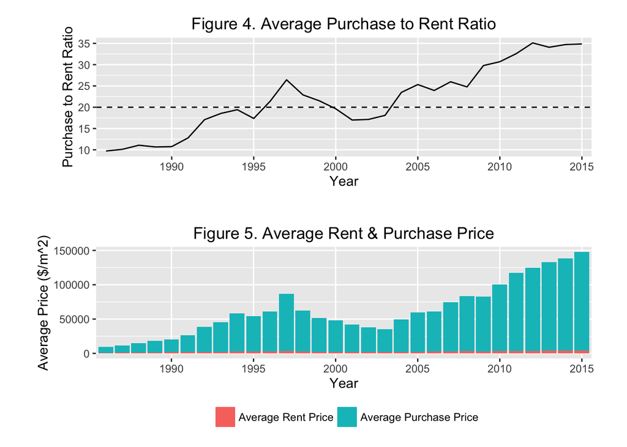

```r
#ggplot

plot4 <- ggplot(data=dfTAvg, aes(x=Year, y=PurchaseToRentRatio)) + geom_line(aes(group=1)) +
                ggtitle("Figure 4. Average Purchase to Rent Ratio") +
                theme(plot.margin=unit(c(0.5,1,1,1.7),"cm")) +
                geom_hline(aes(yintercept=20), linetype="dashed") +
                scale_x_discrete(name="Year", breaks=seq(1985,2015,5)) +
                scale_y_continuous(name="Purchase to Rent Ratio", breaks=seq(0,40,5))

plot5 <- ggplot(data=dfTAvg2, aes(x=Year, y=value,fill = variable)) +
                ggtitle("Figure 5. Average Rent & Purchase Price") +
                geom_bar(position="stack", stat="identity") +
                theme(legend.title=element_blank(), legend.position="bottom") +
                theme(plot.margin=unit(c(0.1,1,0.1,1),"cm")) +
                scale_x_discrete(name="Year", breaks=seq(1985,2015,5)) +
                scale_y_continuous(name="Average Price ($/m^2)", breaks=seq(0,1200000,50000)) +
                scale_fill_discrete(name="Rent/Purchase",
                       breaks=c("AverageRentPrice","AveragePurchasePrice"),
                       labels=c("Average Rent Price","Average Purchase Price"))

grid.arrange(plot4, plot5, nrow=2)
```

As noted previously the purchasing and rental data have been on a huge upswing in recent years. We’ve also seen the Purchase-to-Rent ratio climbing further and further away from the Purchase-to-Rent ratio threshold of 20.

Figure 4. and 5. are averages across all housing classes in Hong Kong. From Figure 4. we can see that the averaged data is crossing over the threshold around 2003 and is averaging a ratio of 35 in recent years. Figure 5. will help further visualize this disparity. From 2003 onwards the aqua bar (Average Purcahse Price) is getting longer and the red bar (Average Rental Price) is relatively flat in comparison.

To conclude, from the charts we can see a large disparity when the cost to buy is around 35 times the annual cost to rent. This is also by no means suggesting Hong Kong rental prices are cheap, because it isn’t. Certainly the cultural perception in the value of time and money is different around the world, but the numbers we see here should at the very least serve as a precaution when making such decisions.

Thank you for reading.

Mitsuaki Takeo